# Fit models

Author

Max Lindmark & Francesca Vitale

Published

2025-09-24

```r
# Load libraries
library(tidyverse)
library(ggaqua)
library(tidylog)
library(sdmTMB)
library(patchwork)
library(viridis)
library(RColorBrewer)
library(modelr)
library(ggtext)
library(tictoc)
library(ggsidekick); theme_set(theme_sleek())

home <- here::here()

# Load all custom functions in R/function

for(fun in list.files(paste0(home, "/R/functions"))){
  source(paste(home, "R/functions", fun, sep = "/"))
}
```

## Read and prepare data

Read data & scale variables. Note we have convert data from catch per hour to catch per area in this [script](https://github.com/maxlindmark/greater-weever/blob/main/R/prepare-data/00-prep-data.qmd), to make better use of the `get_index` function in sdmTMB.

```r
d <- readr::read_csv(paste0(home, "/data/clean/trawl.csv")) |>
  filter(depth > 0) |>
  drop_na(temp) |>
  filter(quarter %in% c(1, 3)) |>
  mutate(temp_sc = as.numeric(scale(temp)),
         depth = log(depth),
         depth_sc = as.numeric(scale(depth)),
         depth_sq = depth_sc*depth_sc,
         quarter_f = as.factor(quarter),
         year_f = as.factor(year))

# Read prediction grid
pred_grid <- readr::read_csv(paste0(home, "/data/clean/pred_grid.csv")) |>
  drop_na(temp) |>
  filter(depth > 0) |>
  mutate(temp_sc = as.numeric(scale(temp)),
         depth = log(depth),
         depth_sc = (depth - mean(d$depth)) / sd(d$depth),
         depth_sq = depth_sc*depth_sc,
         quarter_f = as.factor(quarter),
         year_f = as.factor(year))
```

Fit models. Initial exploration suggest a delta_gamma model [Poisson-link delta gamma](https://pbs-assess.github.io/sdmTMB/articles/web_only/poisson-link.html). Note that we need to put an ar1 on the intercept. Typically we model year as a factor to get independent estimates. However in this case, we are missing q3 data in year 2000. This somehow makes the yearf estimate for 2000 very high, because there’s nothing to inform it I guess except ST fields, which are shared and thereby driven by q1 (and q1 in 2000 is one of the largest years). Allowing the year effect to evolve through time doesn’t mean it estimates separate year effects for each quarter, just that it gets a memory. In theory we could go for a rw0 on time rather than ar1, because correlation is near one, but i get worse diagnistics then.

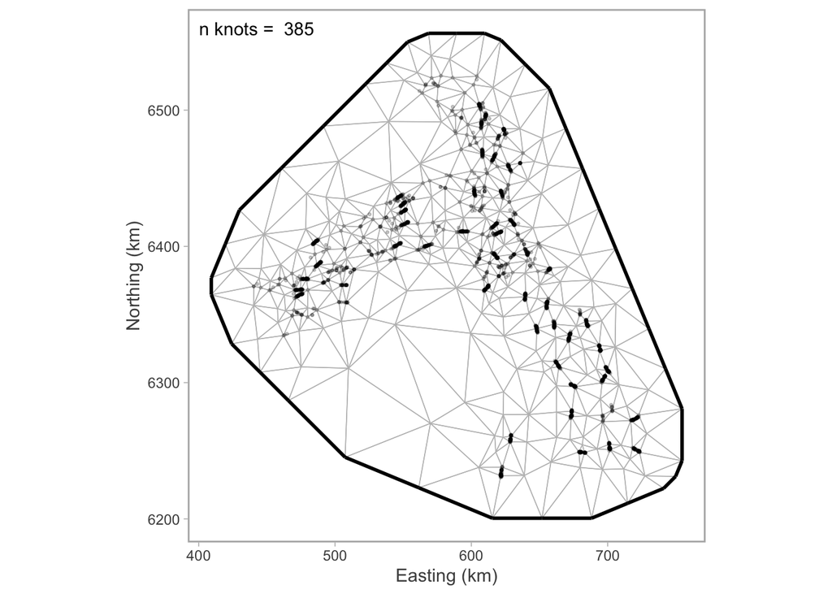

```r
mesh <- make_mesh(d,
                  xy_cols = c("X", "Y"),
                  cutoff = 4)

ggplot() +
  inlabru::gg(mesh$mesh) +
  coord_fixed() +
  geom_point(aes(X, Y), data = d, alpha = 0.2, size = 0.5) +
  annotate("text", -Inf, Inf, label = paste("n knots = ", mesh$mesh$n), hjust = -0.1, vjust = 2) +
  labs(x = "Easting (km)", y = "Northing (km)")
```

We can compare a model with a spatial random effect and one with a spatiotemporal + spatial. Spatiotemporal is IID (for speed).

```r
# Basic model
m0 <- sdmTMB(
  formula = density ~ s(depth_sc) + temp_sc + quarter_f,
  data = d,
  mesh = mesh,
  family = delta_gamma(type = "poisson-link"),
  time_varying = ~1,
  time_varying_type = "ar1",
  spatiotemporal = "off",
  spatial = "off",
  time = "year")

sanity(m0)
```

```
✔ Non-linear minimizer suggests successful convergence
```

```
✔ Hessian matrix is positive definite
```

```
✔ No extreme or very small eigenvalues detected
```

```
✔ No gradients with respect to fixed effects are >= 0.001
```

```
✔ No fixed-effect standard errors are NA
```

```
✔ No standard errors look unreasonably large
```

```
✔ No sigma parameters are < 0.01
```

```
✔ No sigma parameters are > 100
```

Initial exploration suggests the spatiotemporal random field for the binomial model is estimated very small, hence it’s omitted here and only applies to the gamma component.

```r
# Spatiotemporal instead?
tic()
m1 <- sdmTMB(
  formula = density ~ s(depth_sc) + temp_sc + quarter_f,
  data = d,
  mesh = mesh,
  family = delta_gamma(type = "poisson-link"),
  time_varying = ~1,
  time_varying_type = "ar1",
  spatiotemporal = list("off", "iid"),
  spatial = "on",
  time = "year")
toc()
```

```
38.901 sec elapsed
```

```r
sanity(m1)
```

```
✔ Non-linear minimizer suggests successful convergence
```

```
✔ Hessian matrix is positive definite
```

```
✔ No extreme or very small eigenvalues detected
```

```
✔ No gradients with respect to fixed effects are >= 0.001
```

```
✔ No fixed-effect standard errors are NA
```

```
✖ `ln_smooth_sigma` standard error may be large
```

```
ℹ Try simplifying the model, adjusting the mesh, or adding priors
```

```
✔ No sigma parameters are < 0.01
```

```
✔ No sigma parameters are > 100
```

```
✔ Range parameters don't look unreasonably large
```

```r
# Spatiotemporal but squared depth
tic()
m2 <- sdmTMB(
  formula = density ~ depth_sc + depth_sq + temp_sc + quarter_f,
  data = d,
  mesh = mesh,
  family = delta_gamma(type = "poisson-link"),
  time_varying = ~1,
  time_varying_type = "ar1",
  spatiotemporal = list("off", "iid"),
  spatial = "on",
  time = "year")
toc()
```

```
29.116 sec elapsed
```

```r
sanity(m2)
```

```
✔ Non-linear minimizer suggests successful convergence
```

```
✔ Hessian matrix is positive definite
```

```
✔ No extreme or very small eigenvalues detected
```

```
✔ No gradients with respect to fixed effects are >= 0.001
```

```
✔ No fixed-effect standard errors are NA
```

```
✔ No standard errors look unreasonably large
```

```
✔ No sigma parameters are < 0.01
```

```
✔ No sigma parameters are > 100
```

```
✔ Range parameters don't look unreasonably large
```

```r
# Spatiotemporal but squared depth for binomial and linear for gamma
tic()
m3 <- sdmTMB(
  formula = list(density ~ depth_sc + depth_sq + temp_sc + quarter_f,
                 density ~ depth_sc + temp_sc + quarter_f),
  data = d,
  mesh = mesh,
  family = delta_gamma(type = "poisson-link"),
  time_varying = ~1,
  time_varying_type = "ar1",
  spatiotemporal = list("off", "iid"),
  spatial = "on",
  time = "year")
toc()
```

```
26.746 sec elapsed
```

```r
sanity(m3)
```

```
✔ Non-linear minimizer suggests successful convergence
```

```
✔ Hessian matrix is positive definite
```

```
✔ No extreme or very small eigenvalues detected
```

```
✔ No gradients with respect to fixed effects are >= 0.001
```

```
✔ No fixed-effect standard errors are NA
```

```
✔ No standard errors look unreasonably large
```

```
✔ No sigma parameters are < 0.01
```

```
✔ No sigma parameters are > 100
```

```
✔ Range parameters don't look unreasonably large
```

```r
# Spatiotemporal ar1 and squared depth for binomial and linear for gamma
tic()
m4 <- sdmTMB(
  formula = list(density ~ depth_sc + depth_sq + temp_sc + quarter_f,
                 density ~ depth_sc + temp_sc + quarter_f),
  data = d,
  mesh = mesh,
  family = delta_gamma(type = "poisson-link"),
  time_varying = ~1,
  time_varying_type = "ar1",
  spatiotemporal = list("off", "ar1"),
  spatial = "on",
  time = "year")
toc()
```

```
179.812 sec elapsed
```

```r
sanity(m4)
```

```
✔ Non-linear minimizer suggests successful convergence
```

```
✔ Hessian matrix is positive definite
```

```
✔ No extreme or very small eigenvalues detected
```

```
✔ No gradients with respect to fixed effects are >= 0.001
```

```
✔ No fixed-effect standard errors are NA
```

```
✔ No standard errors look unreasonably large
```

```
✔ No sigma parameters are < 0.01
```

```
✔ No sigma parameters are > 100
```

```
✔ Range parameters don't look unreasonably large
```

```r
# Spatiotemporal ar1 and squared depth for binomial and linear for gamma, allow spatial fields to vary with quarter?
tic()
m5 <- sdmTMB(
  formula = list(density ~ depth_sc + depth_sq + temp_sc + quarter_f,
                 density ~ depth_sc + temp_sc + quarter_f),
  data = d,
  mesh = mesh,
  family = delta_gamma(type = "poisson-link"),
  time_varying = ~1,
  time_varying_type = "ar1",
  spatiotemporal = list("off", "ar1"),
  spatial = "off",
  spatial_varying = ~ 0 + quarter_f,
  time = "year")
toc()
```

```
217.071 sec elapsed
```

```r
tidy(m5, effects = "ran_pars")
```

```
# A tibble: 4 × 5
  term     estimate std.error conf.low conf.high
  <chr>       <dbl>     <dbl>    <dbl>     <dbl>
1 range      64.0     15.2      40.1     102.
2 sigma_Z     1.47     0.279     1.01      2.13
3 sigma_Z     1.44     0.261     1.01      2.06
4 rho_time    0.964    0.0402    0.713     0.996
```

```r
sanity(m5)
```

```
✔ Non-linear minimizer suggests successful convergence
```

```
✔ Hessian matrix is positive definite
```

```
✔ No extreme or very small eigenvalues detected
```

```
✔ No gradients with respect to fixed effects are >= 0.001
```

```
✔ No fixed-effect standard errors are NA
```

```
✔ No standard errors look unreasonably large
```

```
✔ No sigma parameters are < 0.01
```

```
✔ No sigma parameters are > 100
```

```
✔ Range parameters don't look unreasonably large
```

AIC favors the spatiotemporal model, with different fields and formula for each component

```r
AIC(m0, m1, m2, m3, m4, m5)
```

```
   df      AIC
m0 15 6353.447
m1 20 5702.803
m2 20 5694.515
m3 19 5693.374
m4 20 5670.378
m5 22 5331.369
```

```r
dd <- d |>
  mutate(res_m5 = residuals(m5),
         res_m0 = residuals(m0)) |>
  pivot_longer(c(res_m5, res_m0))
```

[output not shown]

```
mutate: new variable 'res_m5' (double) with 2,147 unique values and 26% NA
        new variable 'res_m0' (double) with 2,278 unique values and 22% NA
pivot_longer: reorganized (res_m5, res_m0) into (name, value) [was 2908x21, now 5816x21]
```

```
drop_na: removed 1,393 rows (24%), 4,423 rows remaining
```

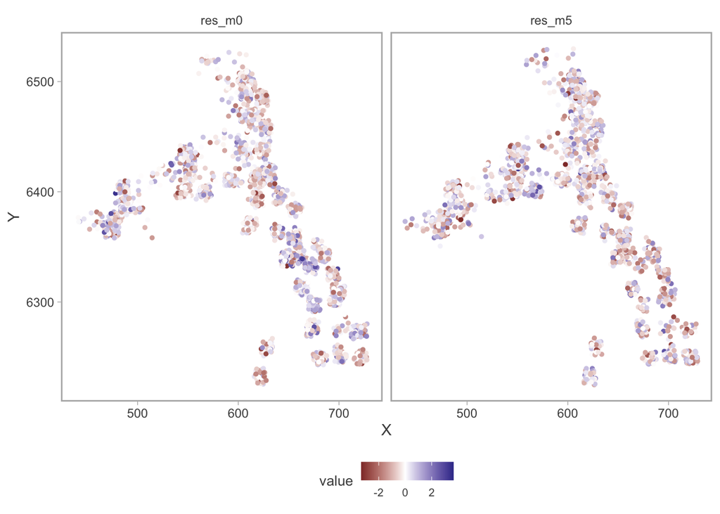

```r
ggplot() +
  geom_jitter(data = dd |> drop_na(value),
              aes(X, Y, color = value),
              width = 6, height = 6, size = 1, alpha = 1) +
  scale_color_gradient2() +
  facet_wrap(~name) +
  theme(legend.position = "bottom")
```

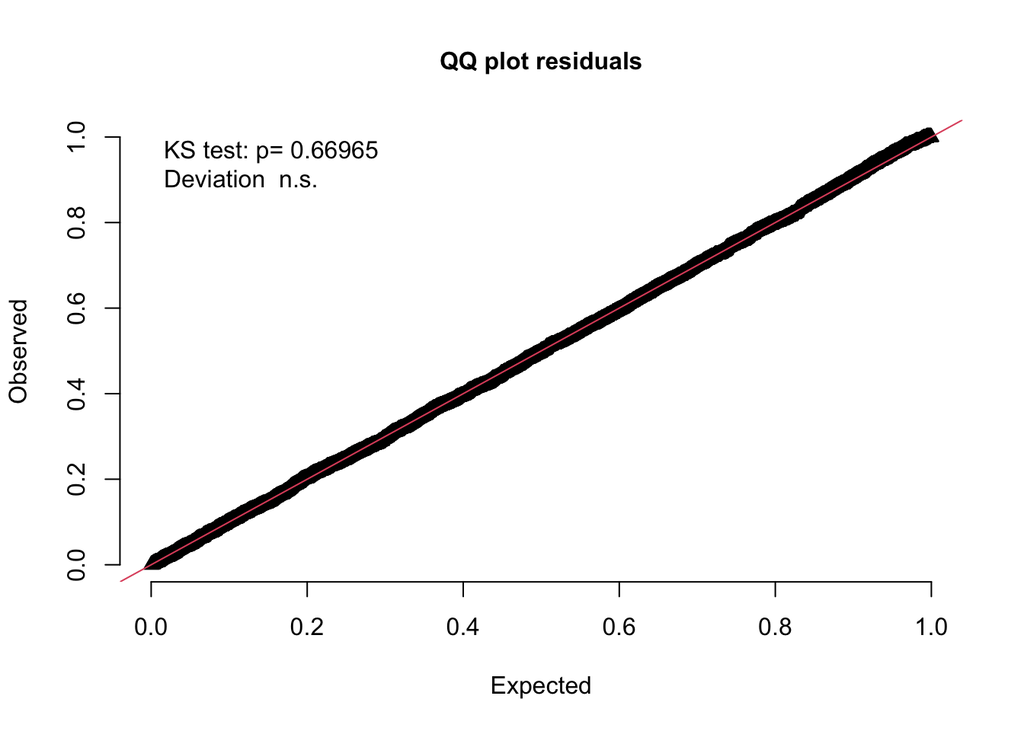

```r
res <- simulate(m5, nsim = 400, type = "mle-mvn") |>
  dharma_residuals(m5)
```

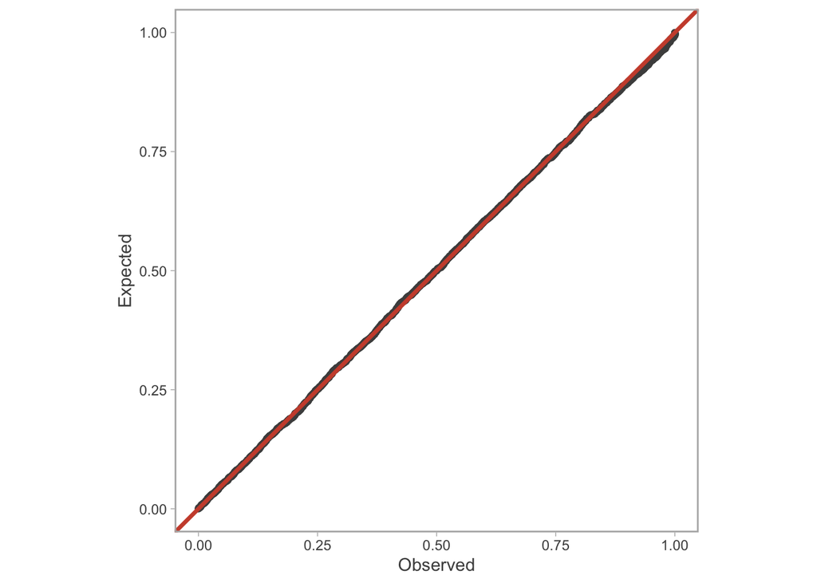

```r
ggplot(res, aes(observed, expected)) +
  geom_point(color = "grey30", shape = 21) +
  geom_abline(col = "tomato3", linewidth = 1.2) +
  theme(aspect.ratio = 1) +
  labs(x = "Observed", y = "Expected")
```

## Conditional effects

```r
# First check coefficients
tidy(m5, exponentiate = TRUE) |>
  as.data.frame()
```

```
         term    estimate    conf.low   conf.high
1 (Intercept)  0.01496481 0.001250895   0.1790281
2    depth_sc  0.14941827 0.087685665   0.2546120
3    depth_sq  0.53177064 0.355301115   0.7958883
4     temp_sc  0.54632682 0.249437103   1.1965862
5  quarter_f3 32.30707248 3.796227278 274.9432149
```

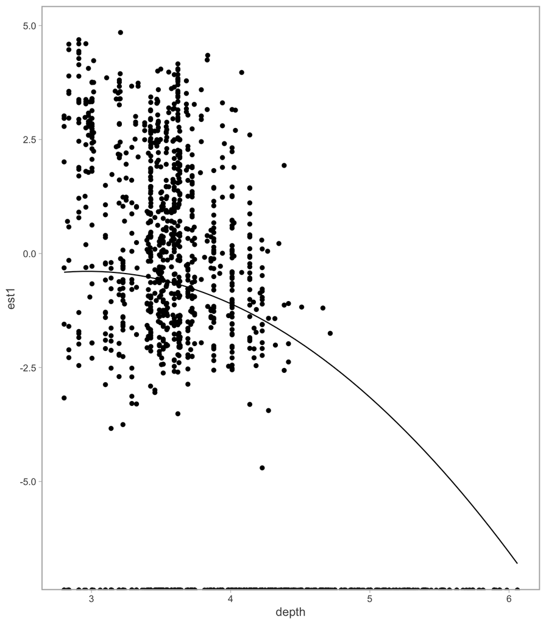

```r
# Depth
# Manual depth prediction
nd_depth <- tibble(depth = modelr::seq_range(d$depth, n = 50)) |>
  mutate(temp_sc = 0,
         depth_sc = as.numeric(scale(depth)),
         depth_sq = depth_sc*depth_sc,
         quarter_f = as.factor(3),
         year = 1999,
         year_f = as.factor(1999))

p_depth <- predict(m5, newdata = nd_depth, re_form = NA, re_form_iid = NA)

ggplot(p_depth, aes(depth, est1)) +
  geom_line() +
  geom_point(data = d, aes(depth, log(density)))
```

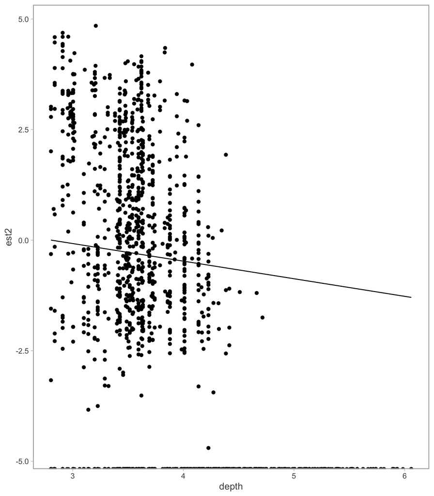

```r
ggplot(p_depth, aes(depth, est2)) +
  geom_line() +
  geom_point(data = d, aes(depth, log(density)))
```

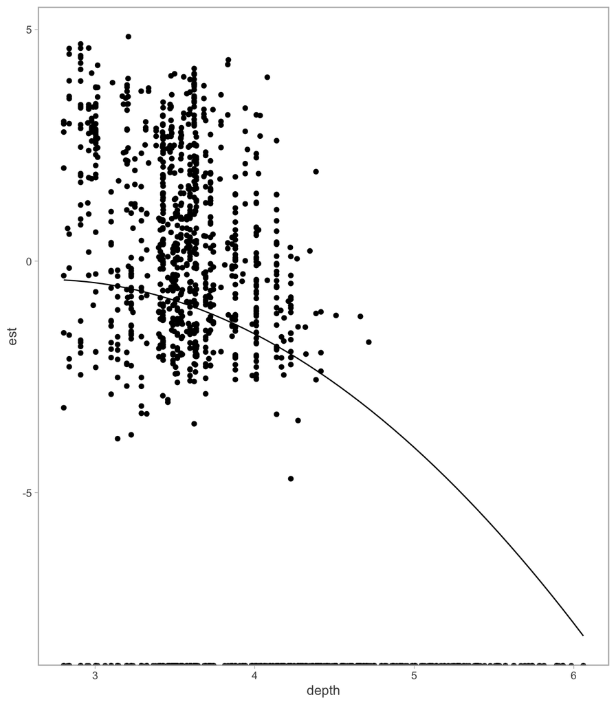

```r
ggplot(p_depth, aes(depth, est)) +
  geom_line() +
  geom_point(data = d, aes(depth, log(density)))
```

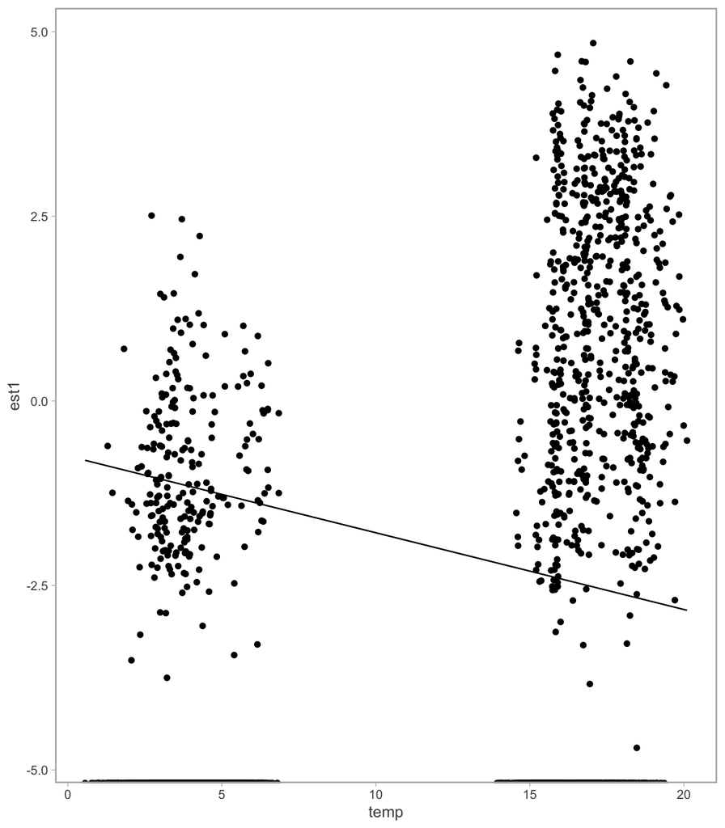

```r
# Manual temperature prediction
nd_temp <- tibble(temp = modelr::seq_range(d$temp, n = 50)) |>
  mutate(temp_sc = as.numeric(scale(temp)),
         depth_sc = 0,
         depth_sq = depth_sc*depth_sc,
         quarter_f = as.factor(3),
         year = 1999,
         year_f = as.factor(1999))

p_temp <- predict(m5, newdata = nd_temp, re_form = NA, re_form_iid = NA)

ggplot(p_temp, aes(temp, est1)) +
  geom_line() +
  geom_point(data = d, aes(temp, log(density)))
```

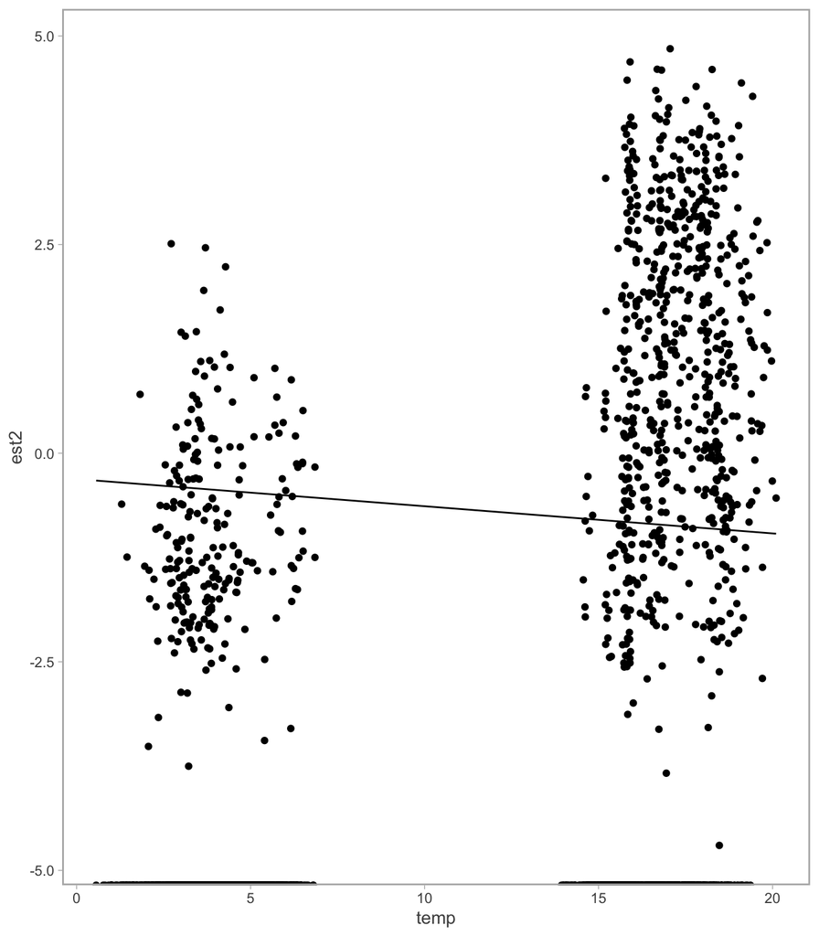

```r
ggplot(p_temp, aes(temp, est2)) +
  geom_line() +
  geom_point(data = d, aes(temp, log(density)))
```

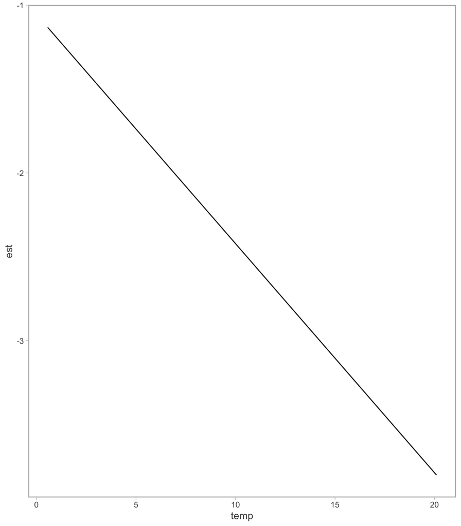

```r
ggplot(p_temp, aes(temp, est)) +
  geom_line()
```

```r
# FIXME interesting that temperature is so negative?!
# Also should I try non linear?
# see how I can plot this nicer with data
```

## Spatial predictions

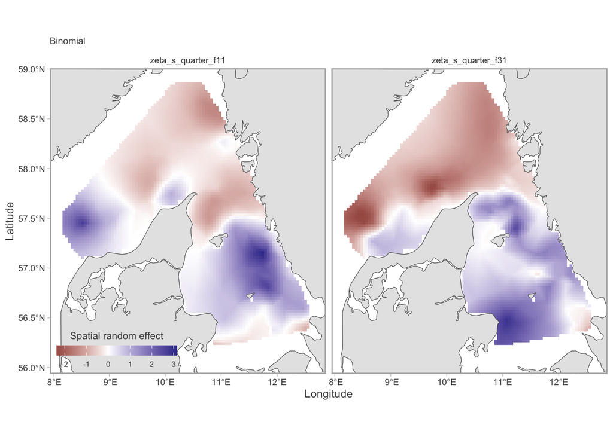

```r
pred <- predict(m5, newdata = pred_grid)

# Spatial random
p1 <- plot_map +
  geom_raster(data = pred |>
                filter(year == max(year)) |>
                pivot_longer(c(zeta_s_quarter_f11, zeta_s_quarter_f31),
                             names_to = "name2"),
              aes(X*1000, Y*1000, fill = value)) +
  scale_fill_gradient2(name = "Spatial random effect") +
  facet_wrap(~ name2) +
  theme_sleek(base_size = 9) +
  theme(legend.position.inside = c(0.12, 0.08),
        legend.direction = "horizontal",
        legend.key.width = unit(0.7, "cm"),
        legend.key.height = unit(0.3, "cm")) +
  guides(fill = guide_colorbar(position = "inside",
                               title.position = "top",
                               title.hjust = 0.5)) +
  geom_sf() +
  labs(subtitle = "Binomial")

p1
```

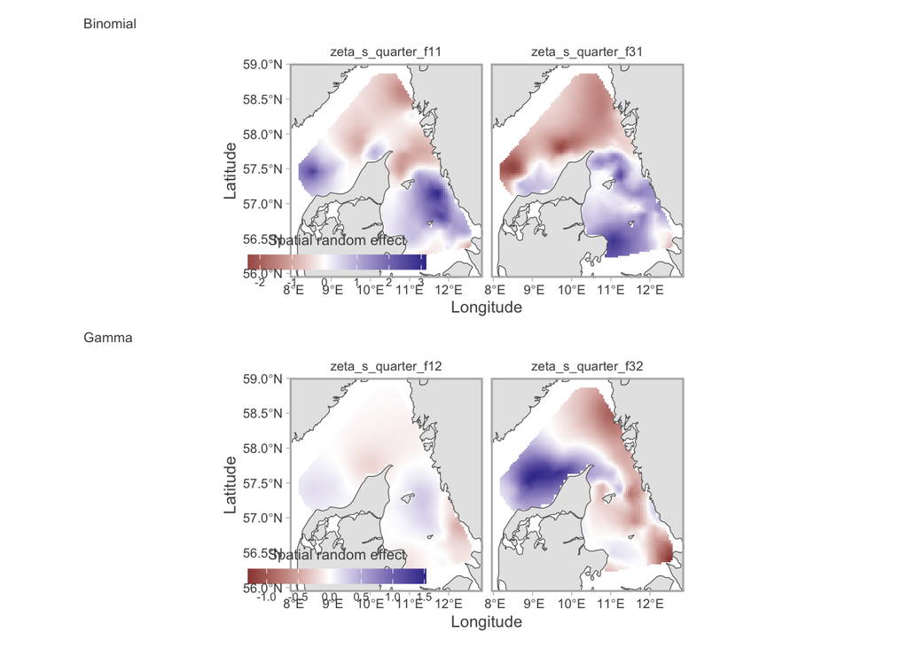

```r
p2 <- plot_map +
  geom_raster(data = pred |>
                filter(year == max(year)) |>
                pivot_longer(c(zeta_s_quarter_f12, zeta_s_quarter_f32),
                             names_to = "name2"),
              aes(X*1000, Y*1000, fill = value)) +
  scale_fill_gradient2(name = "Spatial random effect") +
  facet_wrap(~ name2) +
  theme_sleek(base_size = 9) +
  theme(legend.position.inside = c(0.12, 0.08),
        legend.direction = "horizontal",
        legend.key.width = unit(0.7, "cm"),
        legend.key.height = unit(0.3, "cm")) +
  guides(fill = guide_colorbar(position = "inside",
                               title.position = "top",
                               title.hjust = 0.5)) +
  geom_sf() +
  labs(subtitle = "Gamma")

p1 / p2
```

## Spatiotemporal predictions

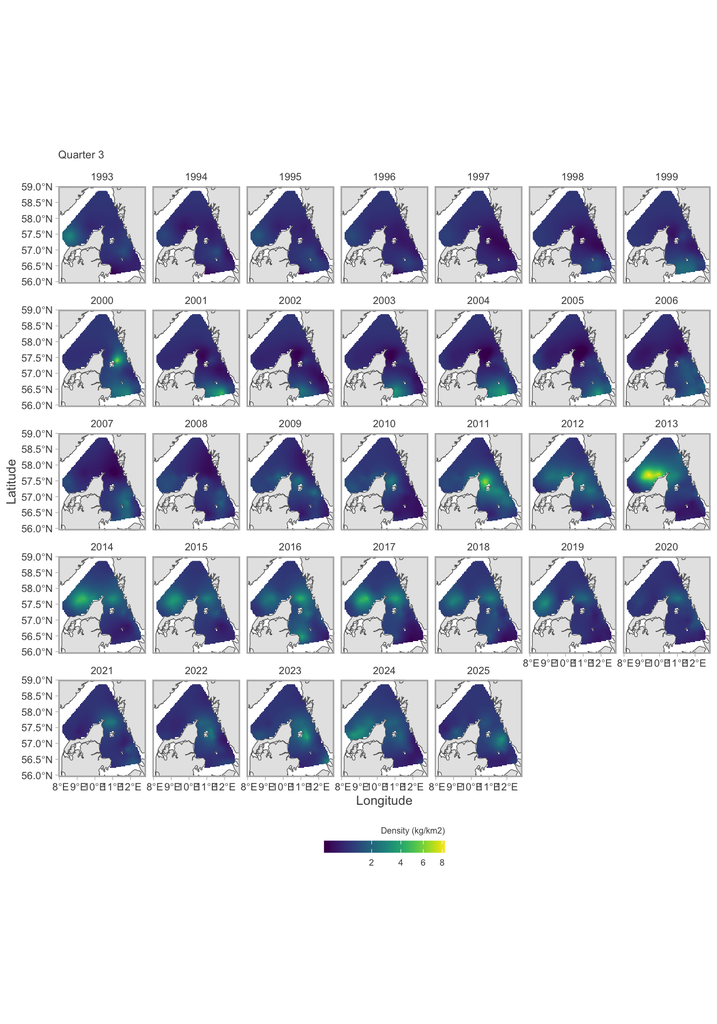

```r
# Total predictions
plot_map_fc +
  geom_raster(data = pred,
              aes(X*1000, Y*1000, fill = exp(epsilon_st2))) +
  scale_fill_viridis(name = "Density (kg/km2)", trans = "sqrt") +
  facet_wrap(~year, ncol = 7) +
  theme_sleek(base_size = 9) +
  theme(legend.position.inside = c(0.195, 0.75),
        legend.direction = "vertical",
        legend.key.width = unit(0.2, "cm"),
        legend.key.height = unit(0.3, "cm"),
        legend.title = element_text(size = 6)) +
  guides(fill = guide_colorbar(
    position = "bottom",
    title.position = "top",
    direction = "horizontal",
    title.hjust = 1,
    theme = theme(legend.key.width  = unit(3, "cm")))) +
  geom_sf() +
  labs(subtitle = "Quarter 3")
```

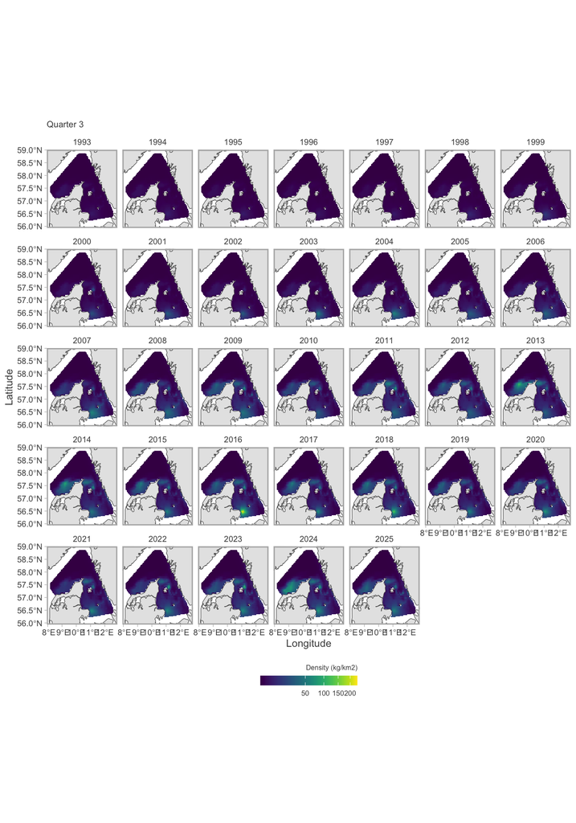

```r
# Total predictions
plot_map_fc +
  geom_raster(data = pred,
              aes(X*1000, Y*1000, fill = exp(est1 + est2))) +
  scale_fill_viridis(name = "Density (kg/km2)", trans = "sqrt") +
  facet_wrap(~year, ncol = 7) +
  theme_sleek(base_size = 9) +
  theme(legend.position.inside = c(0.195, 0.75),
        legend.direction = "vertical",
        legend.key.width = unit(0.2, "cm"),
        legend.key.height = unit(0.3, "cm"),
        legend.title = element_text(size = 6)) +
  guides(fill = guide_colorbar(
    position = "bottom",
    title.position = "top",
    direction = "horizontal",
    title.hjust = 1,
    theme = theme(legend.key.width  = unit(3, "cm")))) +
  geom_sf() +
  labs(subtitle = "Quarter 3")
```

## Plot area occupied over time

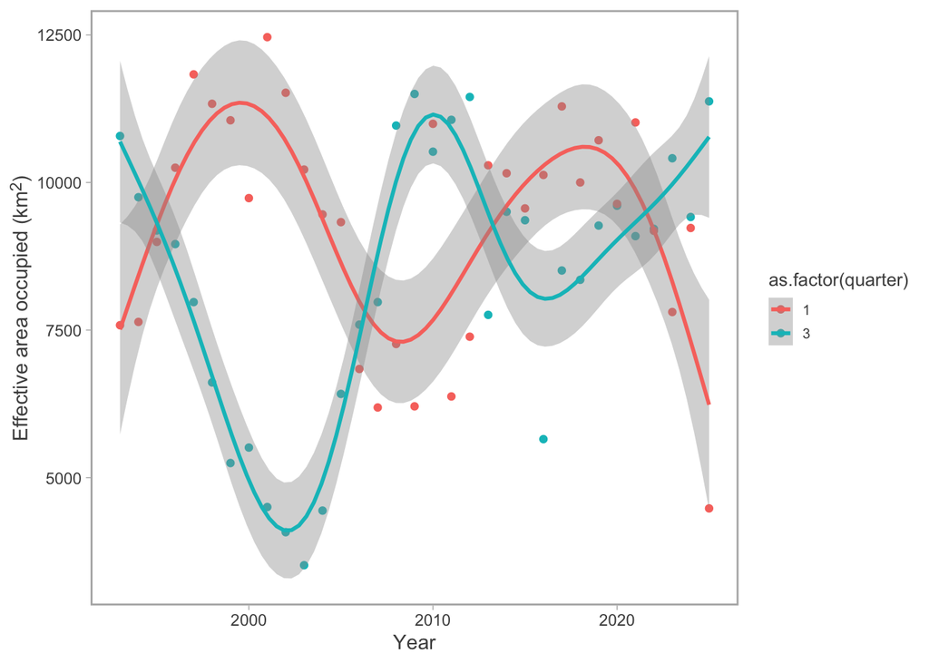

```r
# For get_eao(): A data frame with a columns for time, estimate (effective area occupied; EAO), lower and upper confidence intervals, log EAO, and standard error of the log EAO estimates.
# Thorson, J.T., Rindorf, A., Gao, J., Hanselman, D.H., and Winker, H. 2016. Density-dependent changes in effective area occupied for sea-bottom-associated marine fishes. Proceedings of the Royal Society B: Biological Sciences 283(1840): 20161853. doi:10.1098/rspb.2016.1853
# ‘effective area occupied’ measures the area (in units square km) required to contain a population given its average population density (kg/km2).

pred_tmb_q3 <- predict(
  m5,
  newdata = pred_grid |> filter(quarter == 3),
  return_tmb_object = TRUE)

eao_q3 <- get_eao(pred_tmb_q3, area = 9) |>
  mutate(quarter = 3)

pred_tmb_q1 <- predict(
  m5,
  newdata = pred_grid |> filter(quarter == 1),
  return_tmb_object = TRUE)

eao_q1 <- get_eao(pred_tmb_q1, area = 9) |>
  mutate(quarter = 1)

eao <- bind_rows(eao_q3, eao_q1)

eao |>
  ggplot(aes(year, est, color = as.factor(quarter))) +
  geom_point() +
  labs(y = "Effective area occupied (km<sup>2</sup>)",
       x = "Year") +
  geom_smooth(method = "gam", formula = y~s(x)) +
  theme(axis.title.y = element_markdown())
```

```r
# FIXME: I think many predictions depend on interaction between quarter and not
```

### Get index over time

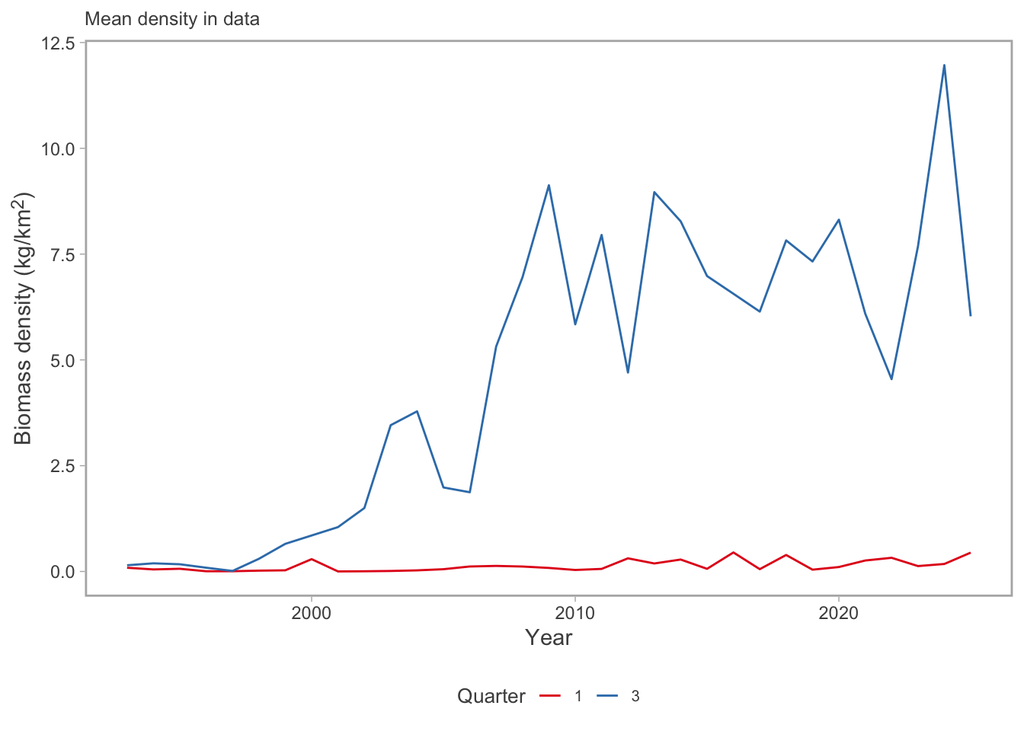

```r
#FIXME there's a spike in the index
# I think it's because in year 2000 i dont have q3 data. but i only have ar1 on the gamma model. so uncertainty is very large

index_q3 <- get_index(pred_tmb_q3, area = 9, bias_correct = TRUE, level = 0.95)

# Mean in data
d |>
  summarise(dens = mean(density), .by = c(quarter, year)) |>
  ggplot(aes(year, dens, color = as.factor(quarter))) +
  geom_line() +
  scale_color_brewer(palette = "Set1", name = "Quarter") +
  theme(legend.position = "bottom",
        axis.title.y = element_markdown()) +
  labs(subtitle = "Mean density in data",
       x = "Year", y = "Biomass density (kg/km<sup>2</sup>)")
```

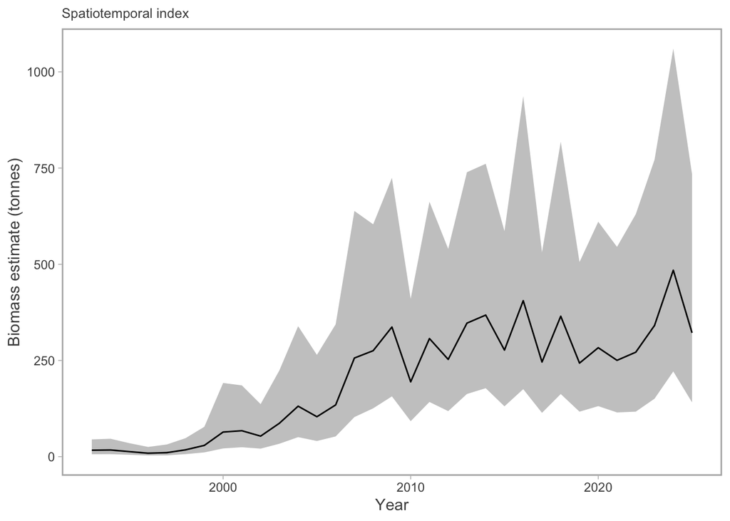

```r
# Index
ggplot(index_q3, aes(year, est/1000)) +
  geom_ribbon(aes(ymin = lwr/1000, ymax = upr/1000), alpha = 0.3, color = NA) +
  geom_line() +
  scale_color_brewer(palette = "Set1") +
  scale_fill_brewer(palette = "Set1") +
    labs(subtitle = "Spatiotemporal index", color = "Quarter",
         fill = "Quarter", x = "Year", y = "Biomass estimate (tonnes)")
```

```r
m5b <- sdmTMB(
  formula = list(density ~ year_f + depth_sc + depth_sq + temp_sc + quarter_f,
                 density ~ year_f + depth_sc + temp_sc + quarter_f),
  data = d,
  mesh = mesh,
  family = delta_gamma(type = "poisson-link"),
  spatiotemporal = list("off", "ar1"),
  spatial = "off",
  spatial_varying = ~ 0 + quarter_f,
  time = "year")

pred_tmb_q3_m5b <- predict(
  m5b,
  newdata = pred_grid |> filter(quarter == 3),
  return_tmb_object = TRUE)
```

```
filter: removed 142,362 rows (50%), 142,362 rows remaining
```

```r
index_q3_m5b <- get_index(pred_tmb_q3_m5b, area = 9, bias_correct = TRUE, level = 0.95)

ind_comp <- bind_rows(
  index_q3 |> mutate(model = "m5"),
  index_q3_m5b |> mutate(model = "m5b")
)
```

```
mutate: new variable 'model' (character) with one unique value and 0% NA
```

```
mutate: new variable 'model' (character) with one unique value and 0% NA
```

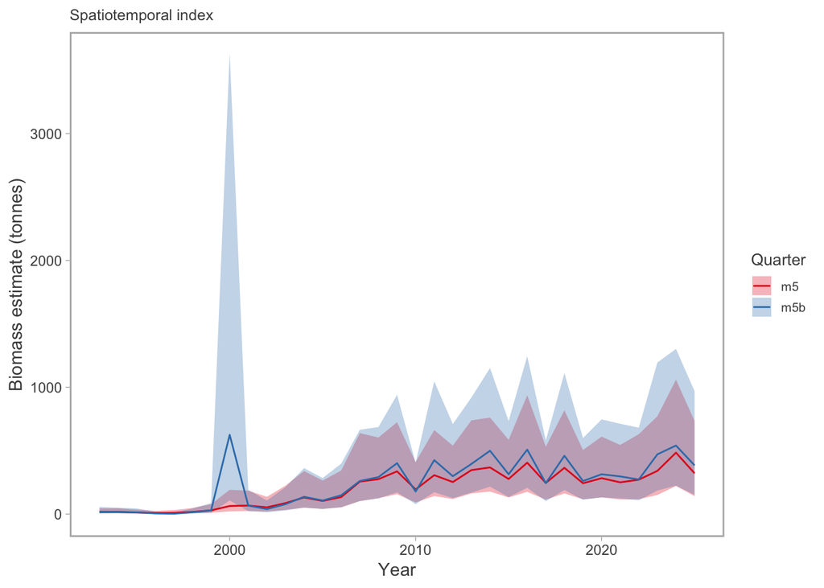

```r
ggplot(ind_comp,
       aes(year, est/1000, fill = model, color = model)) +
  geom_ribbon(aes(ymin = lwr/1000, ymax = upr/1000), alpha = 0.3, color = NA) +
  geom_line() +
  scale_color_brewer(palette = "Set1") +
  scale_fill_brewer(palette = "Set1") +
    labs(subtitle = "Spatiotemporal index", color = "Quarter",
         fill = "Quarter", x = "Year", y = "Biomass estimate (tonnes)")
```

## For ROM

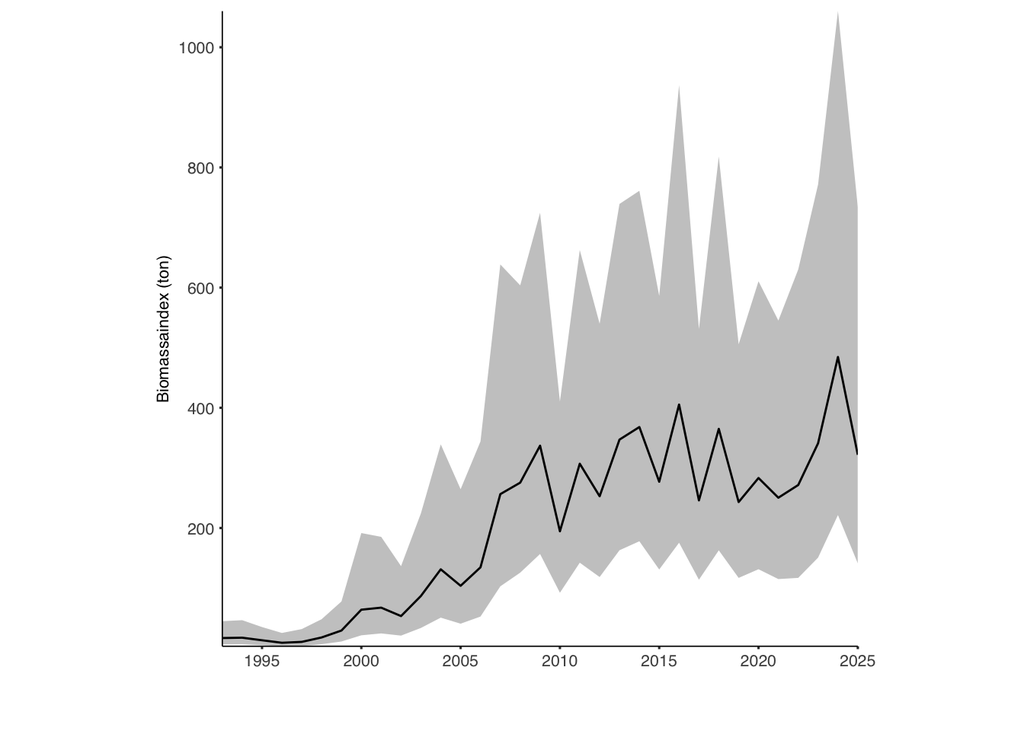

```r
## Index plot
index_q3 |>
  ggplot(aes(year, est/1000)) +
  theme_aqua() +
  scale_x_continuous(expand = c(0, 0), breaks = scales::pretty_breaks(n = 6)) +
  scale_y_continuous(expand = c(0, 0), breaks = scales::pretty_breaks(n = 5)) +
  geom_ribbon(aes(ymin = lwr/1000, ymax = upr/1000), alpha = 0.3, color = NA) +
  geom_line() +
  labs(x = "", y = "Biomassaindex (ton)")
```

```r
ggsave(paste0(home, "/figures/fiskbarometern/Fig_3_maxlindmark.png"),
       dpi = 300, width = 8, height = 8, units = "cm")
```

## What are the temperature trends over time? And how do they relate to the index?

```r
# pred_grid |>
#   summarise("Mean temperature" = mean(temp), .by = c(year)) |>
#   ggplot(aes(year, `Mean temperature`)) +
#   geom_line() +
#   labs(x = "Year") +
#   scale_color_brewer(palette = "Set1") +
#   guides(color = "none")
#
# mean_temps <- pred_grid |>
#   summarise("Mean temperature" = mean(temp), .by = c(year))
#
# index_temp <- index |>
#   left_join(mean_temps, by = c("year"))
#
# eao_temp <- index |>
#   left_join(eao |>
#               rename(eao = est,
#                      lwr_e = lwr,
#                      upr_e = upr) |>
#               dplyr::select(year, eao, lwr_e, upr_e),
#             by = c("year"))
#
# index_temp |>
#   rename(Tonnes = est) |>
#   ggplot(aes(`Mean temperature`, Tonnes)) +
#   geom_point() +
#   theme(aspect.ratio = 1)
#
# # Calculate z-scores and plot over time
# index_temp |>
#   rename(Tonnes = est) |>
#   dplyr::select(year, Tonnes, `Mean temperature`) |>
#   pivot_longer(c(Tonnes, `Mean temperature`)) |>
#   mutate(z = (value - mean(value)) / sd(value), .by = name) |>
#   ggplot(aes(year, z, color = name)) +
#   geom_line() +
#   labs(color = "", x = "Year") +
#   scale_color_brewer(palette = "Set1") +
#   theme(legend.position = "bottom")
#
# # Now area occupied
# eao_temp |>
#   rename(Tonnes = est) |>
#   ggplot(aes(eao, Tonnes)) +
#   geom_point() +
#   theme(aspect.ratio = 1)
#
# eao_temp |>
#   rename(Tonnes = est) |>
#   dplyr::select(year, Tonnes, eao) |>
#   pivot_longer(c(Tonnes, eao)) |>
#   mutate(z = (value - mean(value)) / sd(value), .by = name) |>
#   ggplot(aes(year, z, color = name)) +
#   geom_line() +
#   labs(color = "", x = "Year") +
#   scale_color_brewer(palette = "Set1") +
#   theme(legend.position = "bottom")
```